# Post-adaptation data model fitting experiments

Sebastian Schuster

3/12/2019

```
## # A tibble: 80 x 2
##    workerid catch_perf
##       <dbl>      <int>
##  1     0            13
##  2     1.00          9
##  3     2.00          9
##  4     3.00         12
##  5     4.00         10
##  6     5.00         14
##  7     6.00          8
##  8     7.00         13
##  9     8.00         14
## 10     9.00         13
## # ... with 70 more rows
## [1] "Excluded 19 participants."
##  [1]  1  2  4  6 20 25 27 39 41 46 48 51 52 53 55 66 71 76 78
```

Experiments where we fit parameters of the model to the post-adaptation data to investigate whether the model can learn these parameters and what they would look like.

## Fit 1: Fitting of Thetas and individual costs

In this model, the parameters guiding the distributions over thresholds as well as the costs can vary. There is a separate cost term for each utterance.

Inferred thresholds:

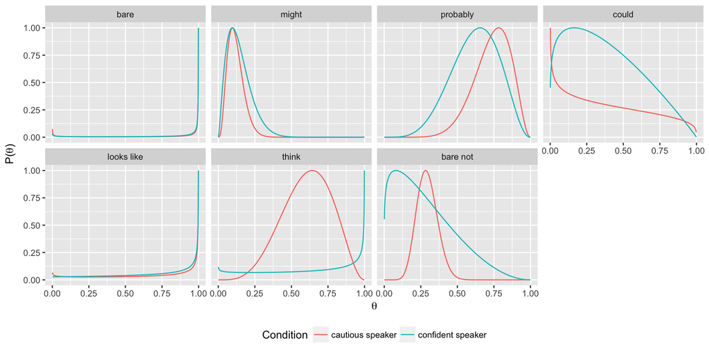

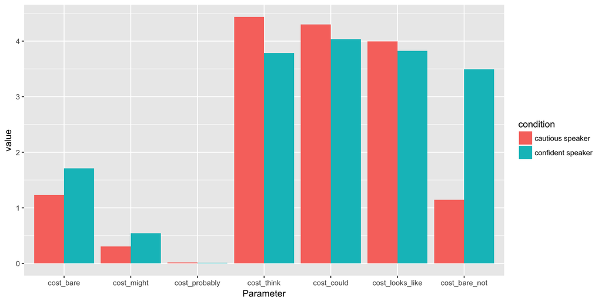

Model fit:

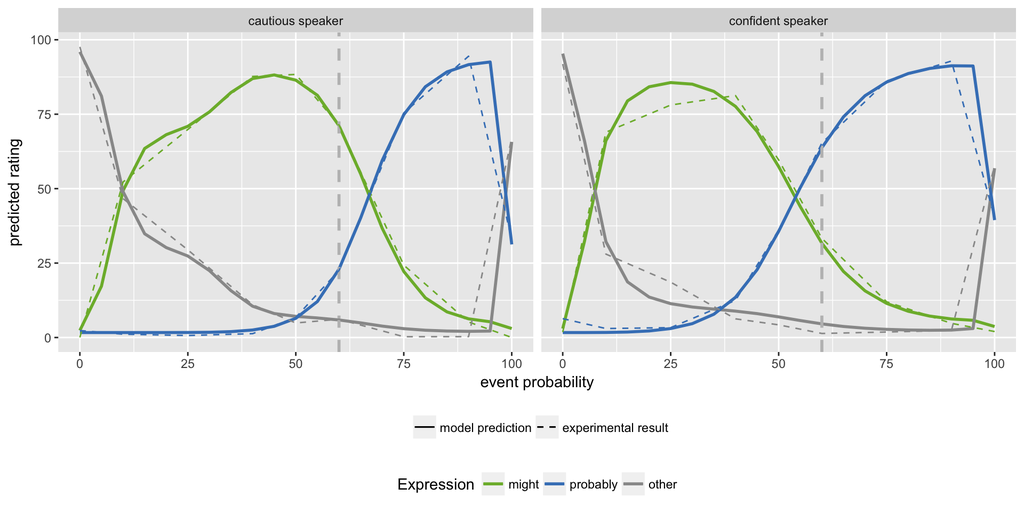

## Fit 2: Fitting of Thetas and individual costs + fixed cost of might and probably

In this model, the parameters guiding the distributions over thresholds as well as the costs can vary. There is a separate cost term for each utterance. The cost of might and probably is fixed and set to 1.

Inferred thresholds:

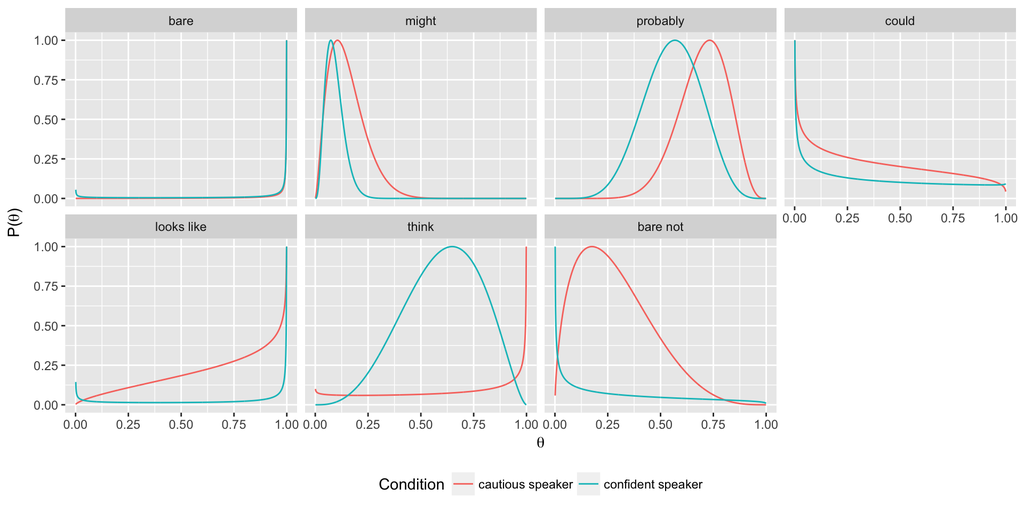

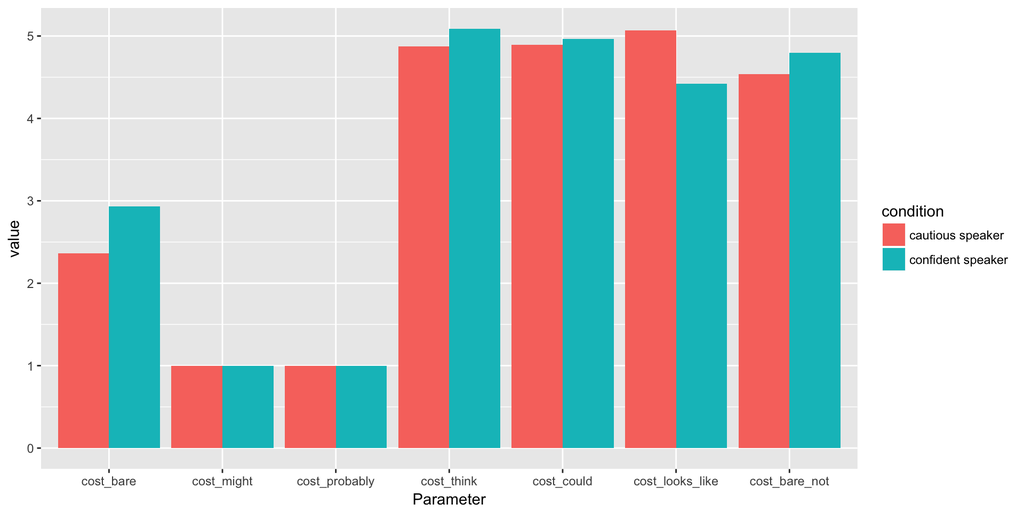

Model fit:

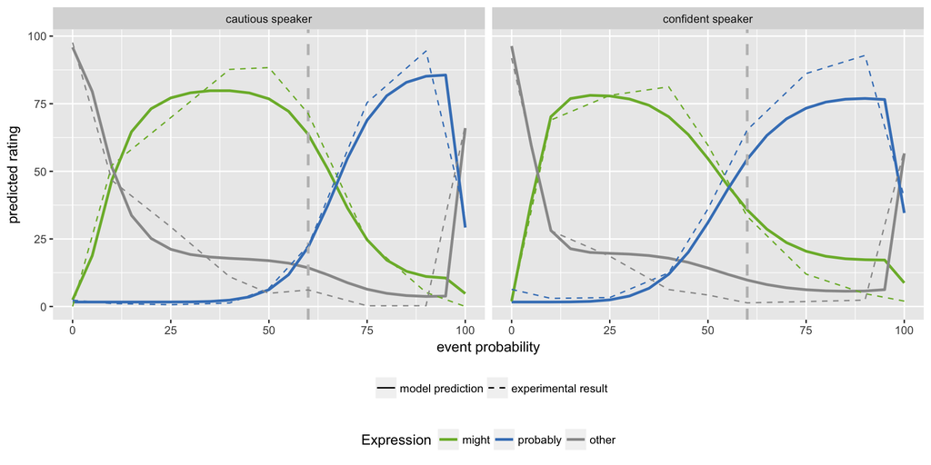

## Fit 3: Fitting of Thetas and 2 free cost parameters (bare and everything else)

In this model, the parameters guiding the distributions over thresholds as well as the costs can vary. There is acost term for the bare form. All other utterances have the same cost (which is updated). The cost of might and probably is fixed and set to 1.

Inferred thresholds:

[output not shown]

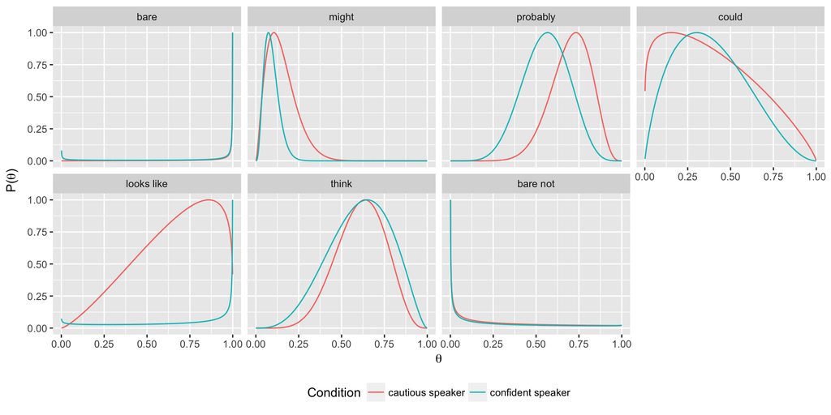

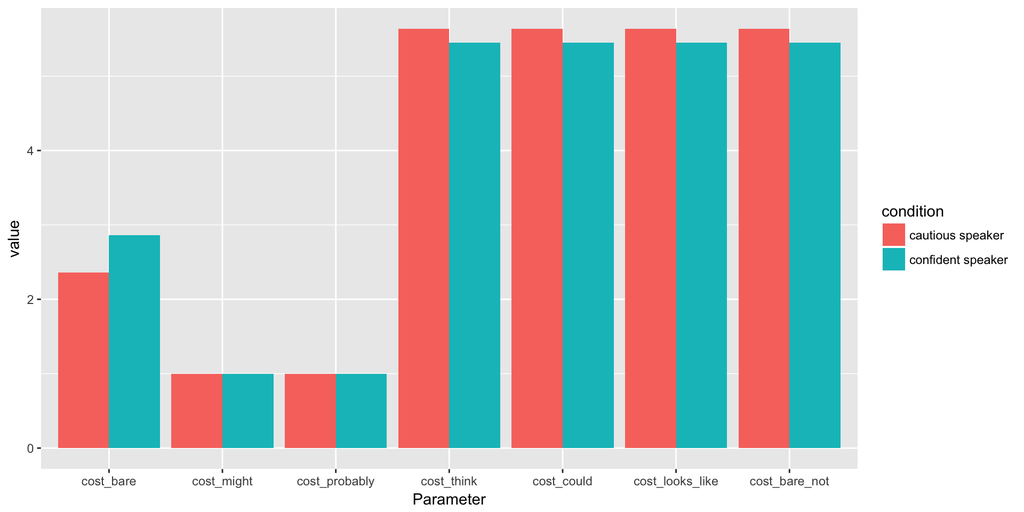

Model fit:

[figure not shown]